# Finding high certainty levels for simple 1d model

Joel Eliason

March 20, 2018

Here, I will principally be concerned with finding initial conditions/data points that will give 99% certainty reconstruction of the simple 1d model and then paring data points/ICs back until we lose that level of certainty.

First, we have a uniform IC density (of 100 ICs) from 0 to 2, with 101 time steps per IC. This allows us to obtain transient behavior for each of these ICs, but not much steady state behavior.

```r
set.seed(123)
step=.01
tf=1
sd=0.1
degree=4
times=seq(0,tf,by=step)
x0=1

ic_step=0.02
ic_f=2
ics=seq(0.01,ic_f,by=ic_step)

df<-lapply(ics, function(z) simple1dsolve(x0=z,step=step,tf=tf,sd=sd,degree=degree))
df<-do.call("rbind",df)

fit<-bas.lm(y1~.,data=df)
summary(fit)
```

```
##           P(B != 0 | Y)    model 1      model 2      model 3      model 4
## Intercept     1.0000000     1.0000 1.000000e+00 1.000000e+00 1.000000e+00
## X1            1.0000000     1.0000 1.000000e+00 1.000000e+00 1.000000e+00
## X2            0.2402548     0.0000 1.000000e+00 1.000000e+00 1.000000e+00
## X3            0.7871924     1.0000 0.000000e+00 1.000000e+00 1.000000e+00
## X4            1.0000000     1.0000 1.000000e+00 1.000000e+00 0.000000e+00
## BF                   NA     1.0000 2.801039e-01 9.031722e-03 1.431649e-09
## PostProbs            NA     0.7597 2.128000e-01 2.740000e-02 0.000000e+00
## R2                   NA     0.9049 9.049000e-01 9.049000e-01 9.045000e-01
## dim                  NA     4.0000 4.000000e+00 5.000000e+00 4.000000e+00
## logmarg              NA 11862.0262 1.186075e+04 1.185732e+04 1.184166e+04
##                model 5
## Intercept 1.000000e+00
## X1        1.000000e+00
## X2        0.000000e+00
## X3        0.000000e+00
## X4        1.000000e+00
## BF        8.149832e-53
## PostProbs 0.000000e+00
## R2        9.025000e-01
## dim       3.000000e+00
## logmarg   1.174209e+04
```

Next, let’s try 100 ICs, but in a much smaller interval: 0 to 1e-4, with the same number of time steps.

```r
ics=seq(0.00001,0.0001,length.out=100)

df<-lapply(ics, function(z) simple1dsolve(x0=z,step=step,tf=tf,sd=sd,degree=degree))
df<-do.call("rbind",df)

fit<-bas.lm(y1~.,data=df)
summary(fit)
```

```
##           P(B != 0 | Y) model 1     model 2     model 3      model 4
## Intercept   1.000000000  1.0000  1.00000000  1.00000000  1.000000000
## X1          0.006843145  0.0000  1.00000000  0.00000000  0.000000000
## X2          0.003536727  0.0000  0.00000000  1.00000000  0.000000000
## X3          0.002244970  0.0000  0.00000000  0.00000000  1.000000000
## X4          0.001718930  0.0000  0.00000000  0.00000000  0.000000000
## BF                   NA  1.0000  0.02611671  0.01287499  0.007715619
## PostProbs            NA  0.9864  0.00640000  0.00320000  0.001900000
## R2                   NA  0.0000  0.00040000  0.00020000  0.000100000
## dim                  NA  1.0000  2.00000000  2.00000000  2.000000000
## logmarg              NA  0.0000 -3.64517976 -4.35246827 -4.864508547
##                model 5
## Intercept  1.000000000
## X1         0.000000000
## X2         0.000000000
## X3         0.000000000
## X4         1.000000000
## BF         0.005608886
## PostProbs  0.001400000
## R2         0.000100000
## dim        2.000000000
## logmarg   -5.183403075
```

100 ICs, [1e-5,1e-4], tf=16

```r
step=.01
sd=0.1
degree=4

x0=1

ics=seq(0.00001,0.0001,length.out=100)
tf=16
times=seq(0,tf,by=step)

df<-lapply(ics, function(z) simple1dsolve(x0=z,step=step,tf=tf,sd=sd,degree=degree))
df<-do.call("rbind",df)

fit<-bas.lm(y1~.,data=df)
summary(fit)
```

```
##           P(B != 0 | Y)     model 1      model 2      model 3      model 4
## Intercept    1.00000000      1.0000 1.000000e+00 1.000000e+00 1.000000e+00
## X1           1.00000000      1.0000 1.000000e+00 1.000000e+00 1.000000e+00
## X2           0.00934883      0.0000 1.000000e+00 1.000000e+00 1.000000e+00
## X3           1.00000000      1.0000 1.000000e+00 0.000000e+00 1.000000e+00
## X4           1.00000000      1.0000 1.000000e+00 1.000000e+00 0.000000e+00
## BF                   NA      1.0000 2.359264e-03 8.489744e-12 6.586662e-35
## PostProbs            NA      0.9907 9.300000e-03 0.000000e+00 0.000000e+00
## R2                   NA      0.7821 7.821000e-01 7.820000e-01 7.819000e-01
## dim                  NA      4.0000 5.000000e+00 4.000000e+00 4.000000e+00
## logmarg              NA 121950.4206 1.219444e+05 1.219249e+05 1.218717e+05
##           model 5
## Intercept       1
## X1              0
## X2              0
## X3              0
## X4              0
## BF              0
## PostProbs       0
## R2              0
## dim             1
## logmarg         0
```

At this range of ICs, with this number of ICs, tf=16 looks to be about as good as it’s going to get (we can go out to about tf=40, but that only gives slight improvements in the post prob).

Let’s try cutting our ICs down by half:

```r
step=.01
sd=0.1
degree=4

x0=1

ics=seq(0.00001,0.0001,length.out=50)
tf=16
times=seq(0,tf,by=step)

df<-lapply(ics, function(z) simple1dsolve(x0=z,step=step,tf=tf,sd=sd,degree=degree))
df<-do.call("rbind",df)

fit<-bas.lm(y1~.,data=df)
summary(fit)
```

```
##           P(B != 0 | Y)    model 1      model 2      model 3      model 4
## Intercept     1.0000000     1.0000 1.000000e+00 1.000000e+00 1.000000e+00
## X1            1.0000000     1.0000 1.000000e+00 1.000000e+00 1.000000e+00
## X2            0.0171186     0.0000 1.000000e+00 1.000000e+00 1.000000e+00
## X3            1.0000000     1.0000 1.000000e+00 0.000000e+00 1.000000e+00
## X4            1.0000000     1.0000 1.000000e+00 1.000000e+00 0.000000e+00
## BF                   NA     1.0000 4.354179e-03 3.716276e-08 2.867206e-14
## PostProbs            NA     0.9829 1.710000e-02 0.000000e+00 0.000000e+00
## R2                   NA     0.7813 7.813000e-01 7.812000e-01 7.811000e-01
## dim                  NA     4.0000 5.000000e+00 4.000000e+00 4.000000e+00
## logmarg              NA 60821.9676 6.081653e+04 6.080486e+04 6.079078e+04
##                 model 5
## Intercept  1.000000e+00
## X1         1.000000e+00
## X2         0.000000e+00
## X3         0.000000e+00
## X4         1.000000e+00
## BF        4.519370e-171
## PostProbs  0.000000e+00
## R2         7.791000e-01
## dim        3.000000e+00
## logmarg    6.042973e+04
```

Then to numICs=10:

```r
step=.01
sd=0.1
degree=4

x0=1

ics=seq(0.00001,0.0001,length.out=10)
tf=16
times=seq(0,tf,by=step)

df<-lapply(ics, function(z) simple1dsolve(x0=z,step=step,tf=tf,sd=sd,degree=degree))
df<-do.call("rbind",df)

fit<-bas.lm(y1~.,data=df)
summary(fit)
```

```
##           P(B != 0 | Y)    model 1      model 2      model 3      model 4
## Intercept     1.0000000     1.0000 1.000000e+00 1.000000e+00 1.000000e+00
## X1            1.0000000     1.0000 1.000000e+00 1.000000e+00 1.000000e+00
## X2            0.3752572     0.0000 1.000000e+00 1.000000e+00 1.000000e+00
## X3            0.6534585     1.0000 0.000000e+00 1.000000e+00 1.000000e+00
## X4            0.9999876     1.0000 1.000000e+00 1.000000e+00 0.000000e+00
## BF                   NA     1.0000 5.546947e-01 1.148605e-02 1.985357e-05
## PostProbs            NA     0.6247 3.465000e-01 2.870000e-02 0.000000e+00
## R2                   NA     0.7840 7.840000e-01 7.840000e-01 7.837000e-01
## dim                  NA     4.0000 4.000000e+00 5.000000e+00 4.000000e+00
## logmarg              NA 12249.9874 1.224940e+04 1.224552e+04 1.223916e+04
##                model 5
## Intercept 1.000000e+00
## X1        1.000000e+00
## X2        0.000000e+00
## X3        1.000000e+00
## X4        0.000000e+00
## BF        5.297096e-34
## PostProbs 0.000000e+00
## R2        7.818000e-01
## dim       3.000000e+00
## logmarg   1.217337e+04
```

That’s pretty significant. Let’s go back to 50 and spread them out over a larger interval:

```r
step=.01
sd=0.1
degree=4

x0=1

ics=seq(0.00001,0.001,length.out=50)
tf=16
times=seq(0,tf,by=step)

df<-lapply(ics, function(z) simple1dsolve(x0=z,step=step,tf=tf,sd=sd,degree=degree))
df<-do.call("rbind",df)

fit<-bas.lm(y1~.,data=df)
summary(fit)
```

```
##           P(B != 0 | Y)    model 1      model 2      model 3      model 4
## Intercept    1.00000000     1.0000 1.000000e+00 1.000000e+00 1.000000e+00
## X1           1.00000000     1.0000 1.000000e+00 1.000000e+00 1.000000e+00
## X2           0.01319986     0.0000 1.000000e+00 1.000000e+00 1.000000e+00
## X3           0.99999825     1.0000 1.000000e+00 0.000000e+00 1.000000e+00
## X4           1.00000000     1.0000 1.000000e+00 1.000000e+00 0.000000e+00
## BF                   NA     1.0000 3.343661e-03 1.777401e-06 2.311900e-16
## PostProbs            NA     0.9868 1.320000e-02 0.000000e+00 0.000000e+00
## R2                   NA     0.7813 7.813000e-01 7.812000e-01 7.811000e-01
## dim                  NA     4.0000 5.000000e+00 4.000000e+00 4.000000e+00
## logmarg              NA 60815.9530 6.081025e+04 6.080271e+04 6.077995e+04
##                 model 5
## Intercept  1.000000e+00
## X1         1.000000e+00
## X2         0.000000e+00
## X3         0.000000e+00
## X4         1.000000e+00
## BF        8.182141e-170
## PostProbs  0.000000e+00
## R2         7.791000e-01
## dim        3.000000e+00
## logmarg    6.042662e+04
```

Let’s spread them by two more orders of magnitude:

```r
step=.01
sd=0.1
degree=4

x0=1

ics=seq(0.00001,0.1,length.out=50)
tf=16
times=seq(0,tf,by=step)

df<-lapply(ics, function(z) simple1dsolve(x0=z,step=step,tf=tf,sd=sd,degree=degree))
df<-do.call("rbind",df)

fit<-bas.lm(y1~.,data=df)
summary(fit)
```

```
##           P(B != 0 | Y)    model 1      model 2      model 3      model 4
## Intercept    1.00000000     1.0000 1.000000e+00 1.000000e+00 1.000000e+00
## X1           1.00000000     1.0000 1.000000e+00 1.000000e+00 1.000000e+00
## X2           0.01396602     0.0000 1.000000e+00 1.000000e+00 1.000000e+00
## X3           0.99996981     1.0000 1.000000e+00 0.000000e+00 1.000000e+00
## X4           1.00000000     1.0000 1.000000e+00 1.000000e+00 0.000000e+00
## BF                   NA     1.0000 3.533305e-03 3.061674e-05 1.639021e-12
## PostProbs            NA     0.9860 1.390000e-02 0.000000e+00 0.000000e+00
## R2                   NA     0.7859 7.859000e-01 7.859000e-01 7.858000e-01
## dim                  NA     4.0000 5.000000e+00 4.000000e+00 4.000000e+00
## logmarg              NA 61678.5674 6.167292e+04 6.166817e+04 6.165143e+04
##                 model 5
## Intercept  1.000000e+00
## X1         1.000000e+00
## X2         0.000000e+00
## X3         0.000000e+00
## X4         1.000000e+00
## BF        4.611279e-125
## PostProbs  0.000000e+00
## R2         7.844000e-01
## dim        3.000000e+00
## logmarg    6.139227e+04
```

And two more:

```r
step=.01
sd=0.1
degree=4

x0=1

ics=seq(0.00001,10,length.out=50)
tf=16
times=seq(0,tf,by=step)

df<-lapply(ics, function(z) simple1dsolve(x0=z,step=step,tf=tf,sd=sd,degree=degree))
df<-do.call("rbind",df)

fit<-bas.lm(y1~.,data=df)
summary(fit)
```

```
##           P(B != 0 | Y)     model 1      model 2 model 3     model 4
## Intercept  1.0000000000      1.0000 1.000000e+00       1      1.0000
## X1         1.0000000000      1.0000 1.000000e+00       0      0.0000
## X2         0.0004823778      0.0000 1.000000e+00       0      1.0000
## X3         1.0000000000      1.0000 1.000000e+00       0      1.0000
## X4         1.0000000000      1.0000 1.000000e+00       0      0.0000
## BF                   NA      1.0000 1.206526e-04       0      0.0000
## PostProbs            NA      0.9995 5.000000e-04       0      0.0000
## R2                   NA      0.9999 9.999000e-01       0      0.9943
## dim                  NA      4.0000 5.000000e+00       1      3.0000
## logmarg              NA 374105.0148 3.740960e+05       0 207006.0525
##             model 5
## Intercept     1.000
## X1            0.000
## X2            1.000
## X3            0.000
## X4            0.000
## BF            0.000
## PostProbs     0.000
## R2            0.726
## dim           2.000
## logmarg   51812.693
```

Spreading it out over that range seemed like a good idea - let’s now cut down the number of ICs again:

```r
step=.01
sd=0.1
degree=4

x0=1

ics=seq(0.00001,10,length.out=2)
tf=16
times=seq(0,tf,by=step)

df<-lapply(ics, function(z) simple1dsolve(x0=z,step=step,tf=tf,sd=sd,degree=degree))
df<-do.call("rbind",df)

fit<-bas.lm(y1~.,data=df)
summary(fit)
```

```
##           P(B != 0 | Y)   model 1      model 2       model 3 model 4
## Intercept   1.000000000     1.000 1.000000e+00  1.000000e+00       1
## X1          1.000000000     1.000 1.000000e+00  1.000000e+00       0
## X2          0.001989162     0.000 1.000000e+00  1.000000e+00       0
## X3          1.000000000     1.000 1.000000e+00  0.000000e+00       0
## X4          1.000000000     1.000 1.000000e+00  1.000000e+00       0
## BF                   NA     1.000 4.982816e-04 5.578001e-321       0
## PostProbs            NA     0.998 2.000000e-03  0.000000e+00       0
## R2                   NA     1.000 1.000000e+00  1.000000e+00       0
## dim                  NA     4.000 5.000000e+00  4.000000e+00       1
## logmarg              NA 17121.563 1.711396e+04  1.638415e+04       0
##            model 5
## Intercept    1.000
## X1           0.000
## X2           0.000
## X3           1.000
## X4           0.000
## BF           0.000
## PostProbs    0.000
## R2           0.974
## dim          2.000
## logmarg   5834.700
```

Let’s try both ICs, independently:

```r
# set.seed(123)
step=.01
sd=0.1
degree=4

x0=1

ics=0.00001
tf=16
times=seq(0,tf,by=step)

df<-lapply(ics, function(z) simple1dsolve(x0=z,step=step,tf=tf,sd=sd,degree=degree))
df<-do.call("rbind",df)

fit<-bas.lm(y1~.,data=df)
summary(fit)
```

```
##           P(B != 0 | Y)   model 1      model 2     model 3      model 4
## Intercept     1.0000000    1.0000    1.0000000    1.000000 1.000000e+00
## X1            1.0000000    1.0000    1.0000000    1.000000 1.000000e+00
## X2            0.2377956    0.0000    0.0000000    1.000000 1.000000e+00
## X3            0.2766503    0.0000    1.0000000    0.000000 1.000000e+00
## X4            0.9244874    1.0000    1.0000000    1.000000 0.000000e+00
## BF                   NA    1.0000    0.2099099    0.165225 8.684344e-02
## PostProbs            NA    0.5797    0.1825000    0.143700 7.550000e-02
## R2                   NA    0.7865    0.7871000    0.787000 7.869000e-01
## dim                  NA    3.0000    4.0000000    4.000000 4.000000e+00
## logmarg              NA 1224.9326 1223.3715106 1223.132140 1.222489e+03
##                model 5
## Intercept 1.000000e+00
## X1        1.000000e+00
## X2        1.000000e+00
## X3        1.000000e+00
## X4        1.000000e+00
## BF        5.352366e-03
## PostProbs 1.860000e-02
## R2        7.871000e-01
## dim       5.000000e+00
## logmarg   1.219702e+03
```

And IC=10:

```r
set.seed(123)
step=.01
sd=0.03
degree=4

x0=1

ics=10
tf=16
times=seq(0,tf,by=step)

df<-lapply(ics, function(z) simple1dsolve(x0=z,step=step,tf=tf,sd=sd,degree=degree))
df<-do.call("rbind",df)

fit<-bas.lm(y1~.,data=df)
summary(fit)
```

```
##           P(B != 0 | Y)    model 1      model 2      model 3       model 4
## Intercept  1.0000000000     1.0000 1.000000e+00 1.000000e+00  1.000000e+00
## X1         1.0000000000     1.0000 1.000000e+00 0.000000e+00  1.000000e+00
## X2         0.0002940932     0.0000 1.000000e+00 1.000000e+00  1.000000e+00
## X3         1.0000000000     1.0000 1.000000e+00 1.000000e+00  0.000000e+00
## X4         1.0000000000     1.0000 1.000000e+00 1.000000e+00  1.000000e+00
## BF                   NA     1.0000 7.354494e-05 6.132644e-12 6.689759e-125
## PostProbs            NA     0.9997 3.000000e-04 0.000000e+00  0.000000e+00
## R2                   NA     1.0000 1.000000e+00 1.000000e+00  1.000000e+00
## dim                  NA     4.0000 5.000000e+00 4.000000e+00  4.000000e+00
## logmarg              NA 11044.0680 1.103455e+04 1.101825e+04  1.075815e+04
##           model 5
## Intercept       1
## X1              0
## X2              0
## X3              0
## X4              0
## BF              0
## PostProbs       0
## R2              0
## dim             1
## logmarg         0
```

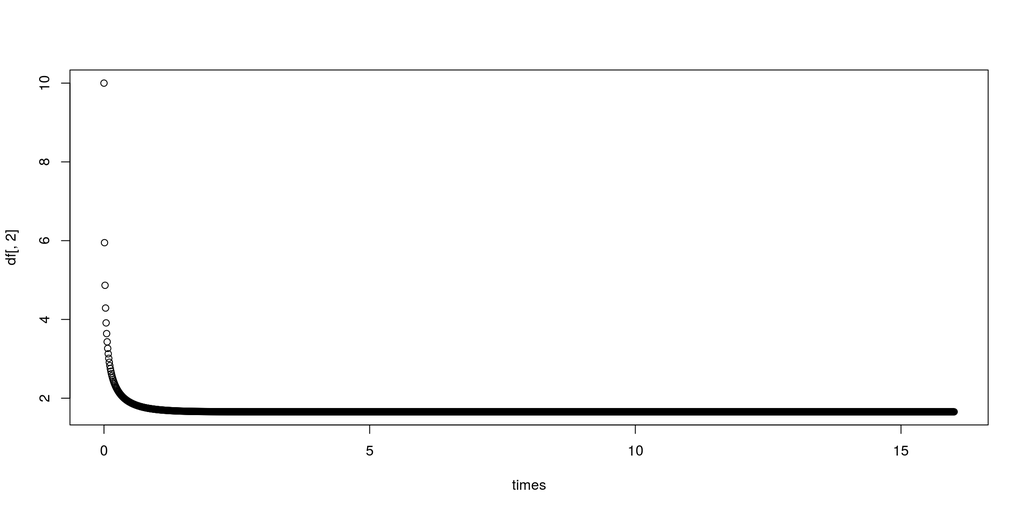

```r
plot(times,df[,2])
```

```r
step=.01
sd=0.1
degree=4

x0=1

ics=10
tf=0.5
times=seq(0,tf,by=step)

df<-lapply(ics, function(z) simple1dsolve(x0=z,step=step,tf=tf,sd=sd,degree=degree))
df<-do.call("rbind",df)

fit<-bas.lm(y1~.,data=df)
summary(fit)
```

```
##           P(B != 0 | Y)  model 1     model 2      model 3      model 4
## Intercept     1.0000000   1.0000   1.0000000 1.000000e+00 1.000000e+00
## X1            0.5888442   1.0000   0.0000000 1.000000e+00 1.000000e+00
## X2            0.4120494   0.0000   1.0000000 1.000000e+00 1.000000e+00
## X3            0.9995773   1.0000   1.0000000 1.000000e+00 0.000000e+00
## X4            1.0000000   1.0000   1.0000000 1.000000e+00 1.000000e+00
## BF                   NA   1.0000   0.6993033 2.002473e-04 7.188784e-04
## PostProbs            NA   0.5880   0.4112000 5.000000e-04 4.000000e-04
## R2                   NA   1.0000   1.0000000 1.000000e+00 1.000000e+00
## dim                  NA   4.0000   4.0000000 5.000000e+00 4.000000e+00
## logmarg              NA 332.1547 331.7970141 3.236387e+02 3.249169e+02
##                model 5
## Intercept 1.000000e+00
## X1        0.000000e+00
## X2        0.000000e+00
## X3        1.000000e+00
## X4        1.000000e+00
## BF        4.433552e-12
## PostProbs 0.000000e+00
## R2        1.000000e+00
## dim       3.000000e+00
## logmarg   3.060129e+02
```

We definitely lose some probability mass, which is odd.

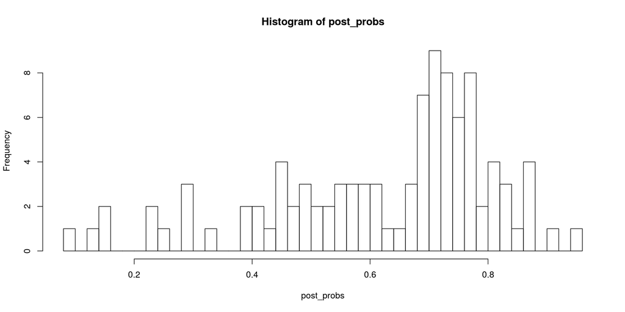

```r
step=.01
sd=0.1
degree=4

ics=10
tf=0.5
times=seq(0,tf,by=step)

numSeeds=100
post_probs<-rep(0,numSeeds)
for (i in 1:numSeeds){
  set.seed(i)
  df<-simple1dsolve(x0=ics,step=step,tf=tf,sd=sd,degree=degree)
  fit<-bas.lm(y1~.,data=df)
  w<-fit$which
  lv=sapply(w,function(z) all(unlist(z)==c(0,1,3,4)))
  idx=min(which(lv == TRUE))
  post_probs[i]=fit$postprobs[idx]
}
hist(post_probs,breaks=40)
```

```r
median(post_probs)
```

```
## [1] 0.6903684
```